# Preliminary results

2022-11-14

## About the data (i)

- Women 40+ Healthy Aging Study (University of Zurich).
- Psychometric instrument to obtain information about the history of romantic relationships of women aged between 40 and 75 years.
- Data collected between June 2017 and February 2018.
- Information about relationship phases starting from the age of 15 years until the current age at the time of the data collection.
- The phases were defined by the start and end age and for each phase and information about civil status, relationship status, living situation, children and quality of the relationship was collected.
- Data from 250 individuals available.

## About the data (ii)

Consider, for example, relationship status:

- No relationship (NR)
- In a relationship (R)
- Open relationship (OR)
- Changing relationships (CR)

A sequence may look as follows:

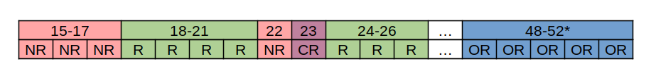

*Current age

## Research question(s)

Find the methods that produce the best clusters of sequences.

- Distances between sequences
- Clustering method
- Clustering performance evaluation metric

## Progress

- Data cleaning/pre-processing
- Data exploration to find the variables to use
- Calculation and evaluation of cost matrix
- First clustering attempt

## Data pre-processing

- Manual corrections (unify sequences with example data or exclude individuals).
- Several checks to exclude sequences with inconsistent data.
- Corrections based on secondary data source.
- Selection of variables to use (five scenarios considered).
- In total, 239 individuals are considered for the analysis.

## Exproratory - Civil status

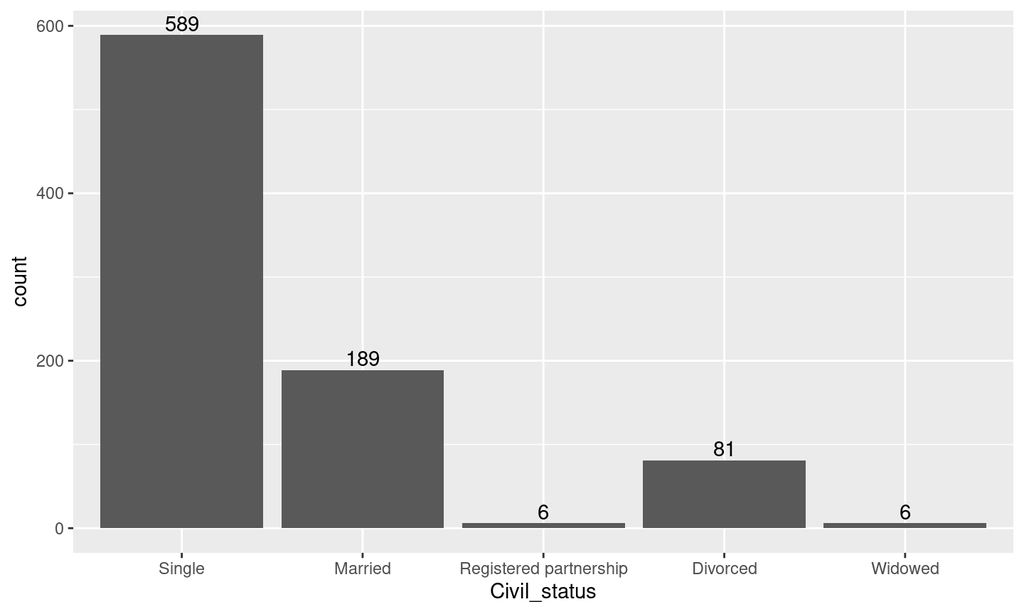

## Exproratory - Relationship status

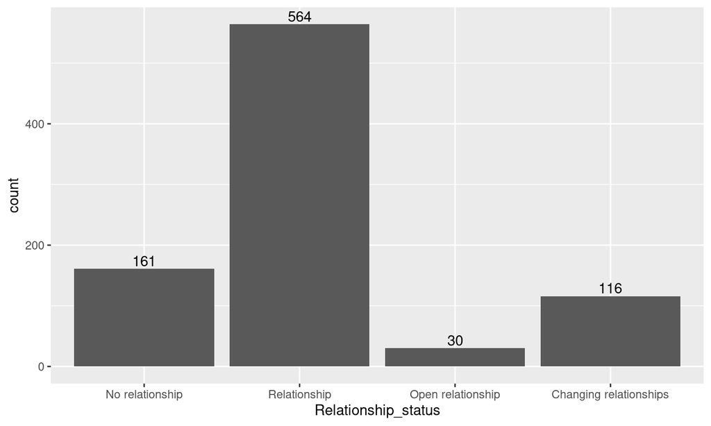

## Exproratory - Civil & relationship status

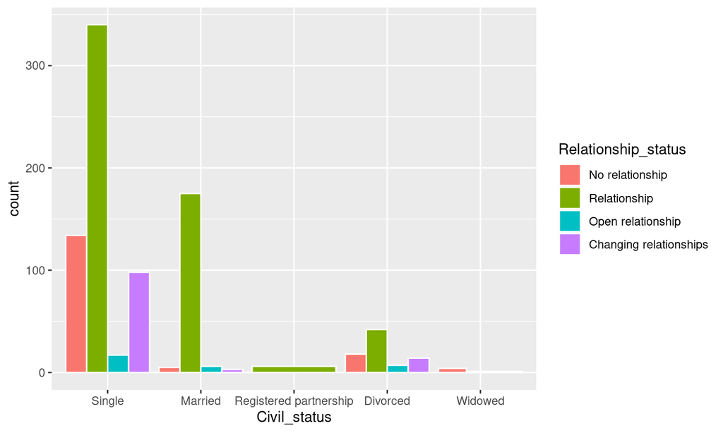

## Exproratory - Living situation

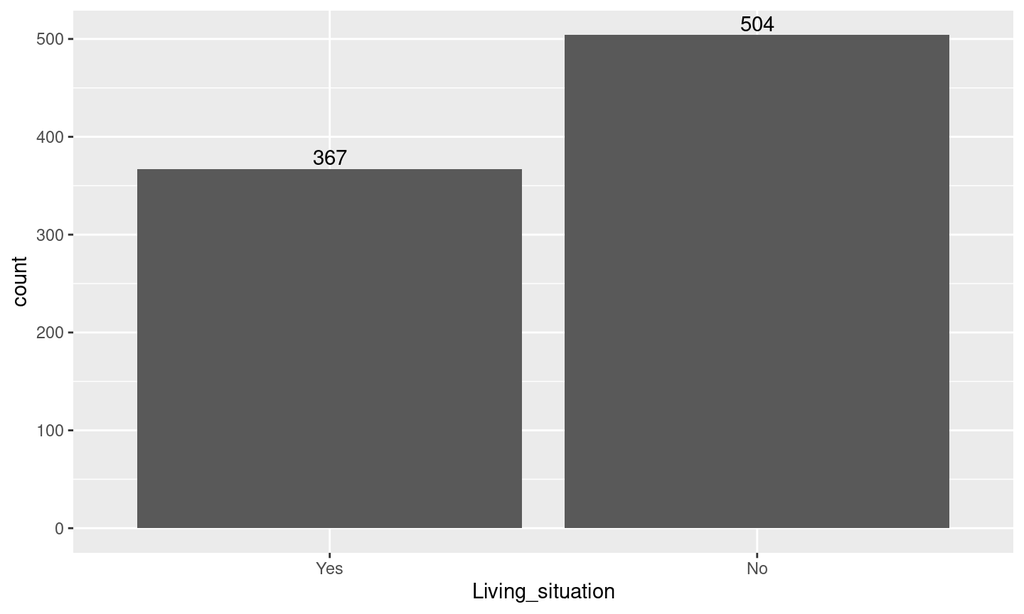

## Exproratory - Children

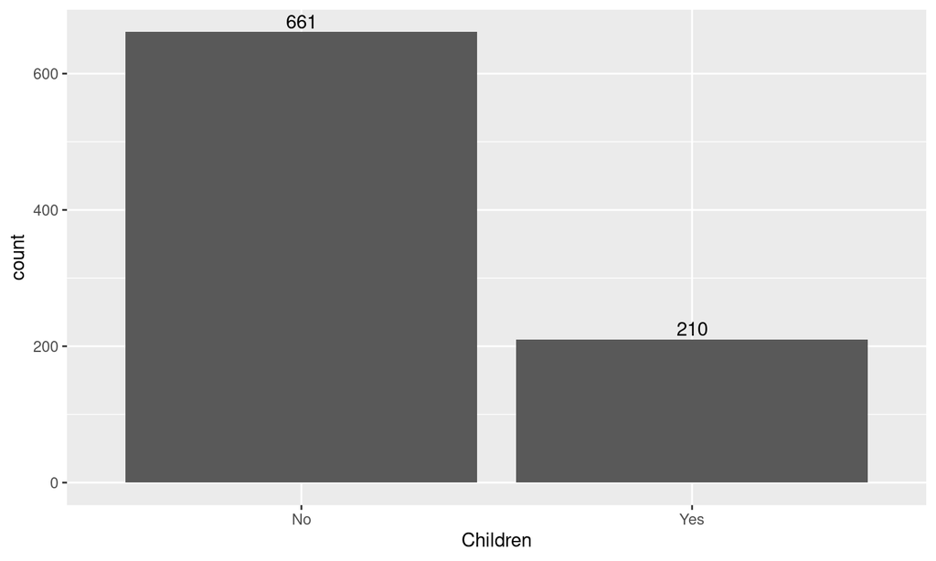

The instrument asked about the number of children in different phases but it will only be considered the presence/absence of children.

## Considered states

- Single + no children
- Relationship + no children + living apart
- Changing relationships + no children
- Married + no children
- Single + children
- Relationship + children + living apart
- Changing rel. + children
- Married + children
- Relationship + no children + living together
- Relationship + children + living together

## Distribution of states

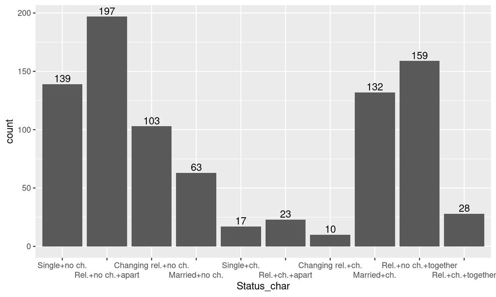

## Optimal Matching Analysis (OMA)

- Technique used in social sciences for the comparison of sequences.
- Applications on life course and career path analysis.
- Given two sequences, it is possible to transform one sequence into another using a set of operations on the states: insert, delete and replace (*edit distance*).
- Numerical values are assigned to each of this operations and are defined in a **cost matrix**.
- As a result, pairwise distances between the sequences can be obtained to apply a clustering method.

## Example (i)

Analyzing Sequence Data: Optimal Matching in Management Research (T. Biemann and D. K. Datta)

- Goal: study career paths of deans at US business schools.
- Data source: 149 CVs of deans including public and private business schools.
- Coded into yearly data with the states: administration (A), corporation (C), faculty (F), government (G).

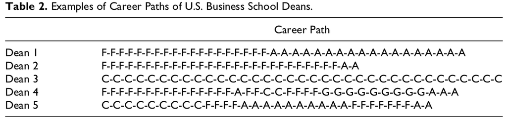

## Example (ii)

Cost matrix:

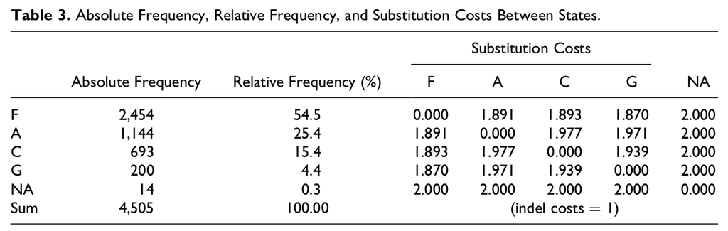

## Example (iii)

Distance/dissimilarities matrix for five deans:

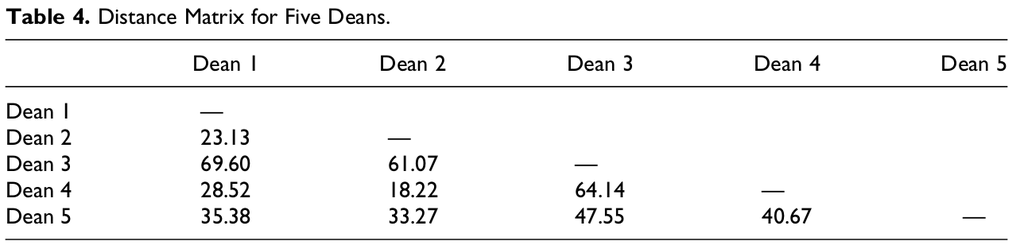

## Example (iv)

Two of the five resulting clusters:

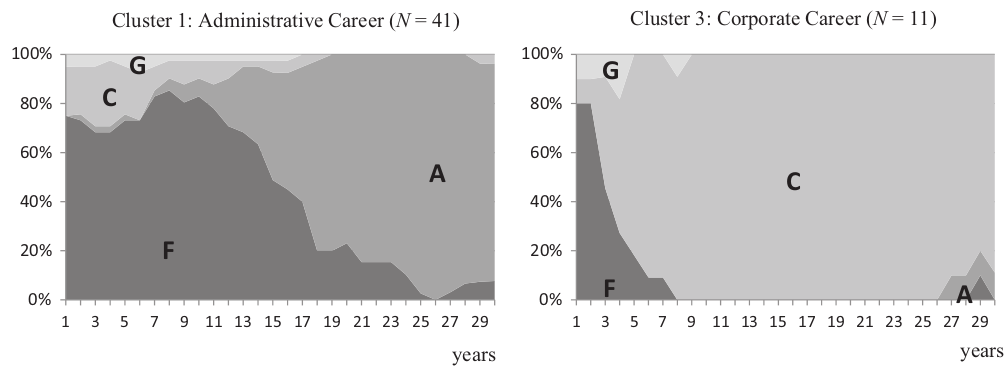

## Cost matrix (i)

Using the `R` package `TraMineR` the cost matrix is calculated with transition rates between states.

Given a set of \(k\) states, say, \(S = \{s_1, \dots, s_k\}\), the substitution cost between states \(s_i\) and \(s_j\), \(1 \leq i, j \leq k\), is calculated as:

\[ C(s_i, s_j) = c - P(s_i|s_j) - P(s_j|s_i) \]

where \(P(s_i|s_j)\) is the probability of transition from state \(s_i\) in time \(t\) to \(s_j\) in time \(t+1\) and \(c\) is a constant (set by default to \(c = 2\) so that \(0 \leq C(i, j) \leq 2\))¸.

## Cost matrix (ii)

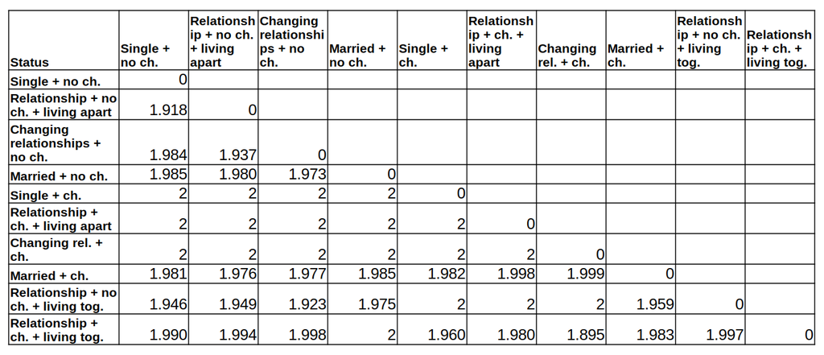

## Distance matrix

- Given \(x, y \in X\) two sequences of interest. There different mappings from \(T: X \to X\) such that \(T(x) = y\).
- \(T\) is composed of elements (operations) that can be insertion, deletion or substitution.
- There is a cost associated with each operation: The substitution cost are given by the cost matrix and insertion/deletion costs are set in a way that reduces/increases the importance of time shifts (low/high).
- The distance between \(x\) and \(y\) is given by the lower cost mapping.

## Clustering (i)

- Hierarchical method: Agglomerative Nesting (AGNES).
- At the beginning each individual is a cluster and, at every step, the closest clusters are merged together.
- Distance between two clusters is the average of the distances between the points in one cluster and the points in the other cluster.
- For the first attempt: 6 clusters.

## Clustering (ii)

Dendrogram:

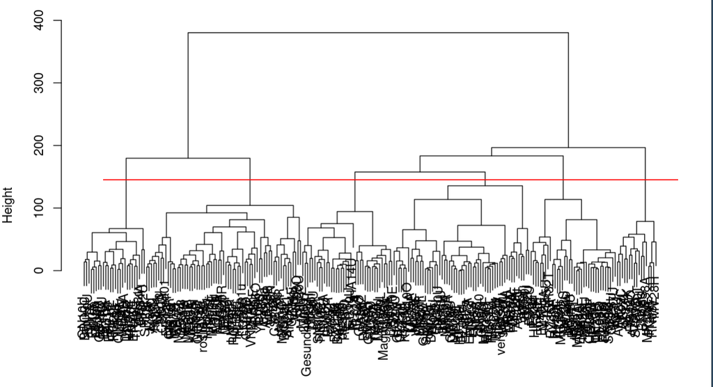

## Clustering (iii)

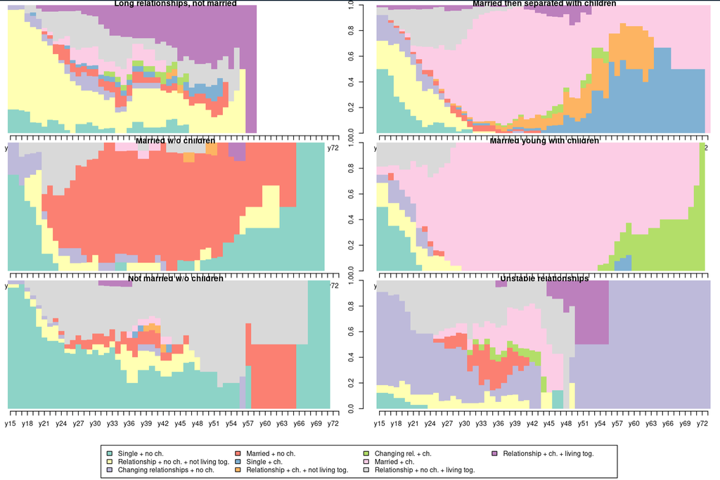

## References

- Sequence Analysis: New Methods for Old Ideas - A. Abbott (1995)
- Optimal Matching Analysis: A Methodological Note on Studying Career Mobility - T. W. Chan (1995)
- Analyzing Sequence Data: Optimal Matching in Management Research - T. Biemann & D. K. Datta (2013)
- Analyzing and Visualizing State Sequences in R with TraMineR - A. Gabadinho, G. Ritschard, N. S. Müller, M. Studer (2011)